# Analysis A: MTTC analysis and raw data plots

This document contains the plotting and statistical analysis of the MTTC scores, and the generation of the raw data plot that displayed TTC, velocity, steer angle, brake depression and lane changing information.

```python
# Define functions and load data
import numpy as np
import pandas as pd
import matplotlib.pyplot as plt
import seaborn as sns
import pickle
from TomsFunctions import *

def MTTCscore(MTTCdf, method = 'median', inverse = False):
    # This function calculates the MTTC score based on the three trials.
    # Function returns the MTTC score based on the mean or median.
    # When inverse = True, the inverse MTTC is returned.
    # method is 'mean' or 'median'

    MTTCscore = {'participant':[], 'score': []}
    for p in MTTCdf['participant'].unique(): #for participants
        currentlist = MTTCdf[MTTCdf['participant'] == p].iloc[:,1]
        MTTCscore['participant'].append(p)
        if method == 'median':
            MTTCscore['score'].append(currentlist.median())
        if method == 'mean':
            MTTCscore['score'].append(currentlist.mean())

    dfout = pd.DataFrame(MTTCscore)
    if inverse:
        dfout = pd.concat([dfout['participant'], dfout['score'].apply(lambda x: 1/x)], axis = 1)
    return dfout

def plot_scores(nouctun_scores, uctun_scores, noucfog_scores, title):
    # add column with run
    nouctun_scores = pd.concat([nouctun_scores, pd.DataFrame({'run': ['nouctun']*len(nouctun_scores)})], axis = 1)
    uctun_scores = pd.concat([uctun_scores, pd.DataFrame({'run': ['uctun']*len(uctun_scores)})], axis = 1)
    noucfog_scores = pd.concat([noucfog_scores, pd.DataFrame({'run': ['foggyroad']*len(noucfog_scores)})], axis = 1)

    merged = pd.concat([nouctun_scores, uctun_scores, noucfog_scores])
    print(merged)
    # Usual boxplot

    fig, ax = plt.subplots(figsize = (6,2))
    sns.set_context('paper', font_scale=1.5)

#     plt.tight_layout()
    sns.set_style('whitegrid')
    sns.boxplot(y='run', x='score', data=merged, ax=ax, color = 'skyblue')

    # Add jitter with the swarmplot function.
    sns.swarmplot(y='run', x='score', data=merged, color=".25", ax = ax)
    plt.yticks([0,1,2],['MU-HU','MU-HU-uc','MC-HU'])
    plt.xlabel('MTTC (s)')
    plt.tight_layout()
    return merged

def plot_differences(merged_df, runA, runB, binwidth):
    scoreA = merged_df.loc[merged_df['run'] == runA, 'score']
    scoreB = merged_df.loc[merged_df['run'] == runB, 'score']

    diff = scoreA - scoreB
    fig, ax = plt.subplots()
    plt.hist(x = diff, bins=np.arange(min(diff), max(diff) + binwidth, binwidth))
    return diff


# Load MTTC scores per trial
MTTCnouctun = load_obj('MTTCnouctun')
MTTCnoucfog = load_obj('MTTCnoucfog')
MTTCuctun = load_obj('MTTCuctun')

# Load list of participants
participants = load_obj('participants')
```

## Caculation of MTTC scores and plotting them.

This image generated here was used in the Results section of the paper.

```
   participant     score        run
0         XSMS  1.515420    nouctun
1         SPPV  1.397835    nouctun
2         TTQW  0.989241    nouctun
3         NNTZ  0.814999    nouctun
4         TWOU  1.397002    nouctun
5         MVNT  1.124491    nouctun
6         ZPQX  1.353303    nouctun
7         PVNT  1.009239    nouctun
8         OYWO  2.621678    nouctun
9         PVOU  1.028313    nouctun
10        WVPV  0.811506    nouctun
11        TTVN  0.909387    nouctun
12        QPMS  0.985686    nouctun
13        UVUM  1.436255    nouctun
```

[output cut: 28 more lines]

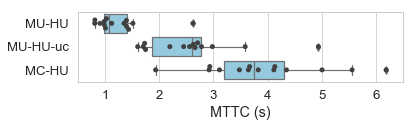

```python
%matplotlib inline

method = 'mean'
nouctun_scores = MTTCscore(MTTCnouctun, method, inverse = False)
noucfog_scores = MTTCscore(MTTCnoucfog, method, inverse = False)
uctun_scores = MTTCscore(MTTCuctun, method, inverse = False)
noinv_df = plot_scores(nouctun_scores, uctun_scores, noucfog_scores, '')
plt.ylabel('')
plt.tight_layout()
# plt.savefig('figs/MTTCbox.eps')
```

```python
import numpy as np
import pylab
import scipy.stats as stats
```

## Visually evaluating the distribution of difference between groups for justification of using a paired t-test

See appendix C.3.1.

```
Text(0,0.5,'Frequency')
```

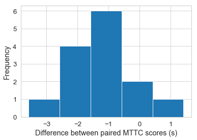

```python
%matplotlib inline
diff_nouctun_uctun = plot_differences(noinv_df, 'nouctun', 'uctun', binwidth = 1)
plt.xlabel('Difference between paired MTTC scores (s)')
plt.ylabel('Frequency')
```

```
((array([-1.66151682, -1.18948235, -0.88997893, -0.65463235, -0.45108016,
         -0.2648058 , -0.08735875,  0.08735875,  0.2648058 ,  0.45108016,
          0.65463235,  0.88997893,  1.18948235,  1.66151682]),
  array([-3.58089444, -2.57596857, -1.99475255, -1.86954243, -1.8470871 ,
         -1.46173848, -1.43678152, -1.31150034, -1.23205915, -0.89413899,
         -0.6808969 , -0.57507936, -0.3121034 ,  0.89030826])),
 (1.1154020536717681, -1.3487310687101928, 0.9769779371256501))
```

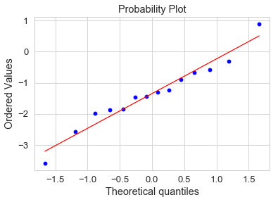

```python
fig, ax= plt.subplots()
stats.probplot(diff_nouctun_uctun, dist="norm", plot=pylab)
```

```
Text(0,0.5,'Frequency')
```

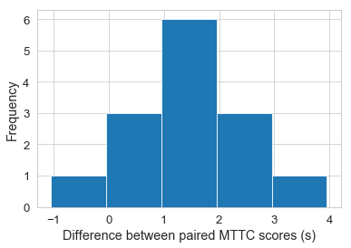

```python
diff_foggyroad_uctun = plot_differences(noinv_df, 'foggyroad', 'uctun', binwidth = 1)
plt.xlabel('Difference between paired MTTC scores (s)')
plt.ylabel('Frequency')
```

```
((array([-1.66151682, -1.18948235, -0.88997893, -0.65463235, -0.45108016,
         -0.2648058 , -0.08735875,  0.08735875,  0.2648058 ,  0.45108016,
          0.65463235,  0.88997893,  1.18948235,  1.66151682]),
  array([-1.04638164,  0.35861891,  0.52789845,  0.91489186,  1.00416142,
          1.01419172,  1.02755311,  1.20139538,  1.24711   ,  1.63683923,
          2.12020534,  2.22208775,  2.52687425,  3.80729411])),
 (1.171556570025522, 1.3259099929348452, 0.9628424727210374))
```

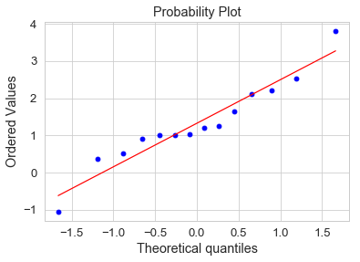

```python
fig, ax = plt.subplots()
stats.probplot(diff_foggyroad_uctun, dist="norm", plot=pylab)
```

# Paired t-test

We decided to use the paired t-test, as the difference between scores seem reasonably near the normal distribution, so we assume the sample distribution is as well. For completeness, we calculate cohen's d, where the denominator is the pooled standard deviation.

```python
from scipy import stats
from numpy import std, mean, sqrt

def cohen_d(x,y):
# denominator is pooled standard deviation which is generally only appropriate
# if the population standard deviation is equal for both groups:
    nx = len(x)
    ny = len(y)
    dof = nx + ny - 2
    return (mean(x) - mean(y)) / sqrt(((nx-1)*std(x, ddof=1) ** 2 + (ny-1)*std(y, ddof=1) ** 2) / dof)

a = noinv_df.loc[noinv_df['run'] == 'nouctun', 'score']
b = noinv_df.loc[noinv_df['run'] == 'uctun', 'score']
c = noinv_df.loc[noinv_df['run'] == 'foggyroad', 'score']


Ttest_nouctun_uctun = stats.ttest_rel(a, b)
Ttest_uctun_foggyroad = stats.ttest_rel(b, c)
d_nouctun_uctun = cohen_d(a,b)
d_uctun_foggyroad = cohen_d(b,c)

print('MC-HU vs MU-HU-uc:', Ttest_nouctun_uctun, 'd =', d_nouctun_uctun)
print('MU-HU vs MU-HU-uc', Ttest_uctun_foggyroad, 'd =', d_uctun_foggyroad)
```

[output not shown]

# Extracting slices from recordings based on time stamps

```python
#Load time stamps. Stamps were identified in GetTTPStamps.ipynb
stamps = load_obj('fogstamps_final')
slice_df = load_obj('FogSlices')
```

Since this cell takes a lot of time to process, we uncommented it and loaded the processed values in the previous cell.

```python
# dfout = pd.DataFrame(columns = ['MeasurementTime', 'steer', 'brake', 'vEgo', 'ttc_min', 'participant',
#        'run', 't_sliceA', 't_sliceB', 'lane', 'sliceno'])
# for p in participants:
#     for r in ['noucfog', 'nouctun', 'uctun']:
#         df = pd.read_csv(f'00Taken/SilabEssentials/{p}{r}.csv', index_col = 0)
#         slices = stamps[(stamps['direction'] == 'FR') & (stamps['participant'] == p)
#                         & (stamps['run'] == r)]

#         sliceno = 0
#         for _, row in slices.iterrows():
#             sliceno += 1
#             sliced = slice_df(df, 'MeasurementTime', row['t_ttp9'], row['t_pass'])
#             #also get laneidx
#             si,_ = load_recordings(p,r, '00EarlyData/Participants')
#             si = si[['MeasurementTime','LaneIdx']]
#             slicedLane = slice_df(si, 'MeasurementTime', row['t_ttp9'], row['t_pass'])
#             sliced = sliced[['MeasurementTime', 'steer', 'brake', 'vEgo', 'ttc_min']]
#             #add participant and run to sliced:
#             sliced['participant'] = [p] * len(sliced)
#             sliced['run'] = [r] * len(sliced)
#             sliced['t_sliceA'] = sliced['MeasurementTime'] - row['t_ttp9']
#             sliced['t_sliceB'] = sliced['MeasurementTime'] - row['t_pass']
#             sliced['lane'] = slicedLane['LaneIdx']
#             sliced['sliceno'] = sliceno
#             dfout = pd.concat([dfout, sliced])


# dfout = dfout.reset_index()

# save_obj(dfout, 'FogSlices')
```

```python
tA = np.round(slice_df['t_sliceA']).astype(int)
tB = np.round(slice_df['t_sliceB']).astype(int)
tA.name = 'tA'
tB.name = 'tB'
slice_df = pd.concat([slice_df, tA, tB], axis = 1)
slice_df.head()

plotdf = slice_df[::5000]
len(plotdf)
```

The dataframe with slices looks as follows (only showing first 5 entries):

```python
slice_df.head()
```

|  | MeasurementTime | steer | brake | vEgo | ttc_min | participant | run | t_sliceA | t_sliceB | lane | sliceno | tA | tB |
| --- | --- | --- | --- | --- | --- | --- | --- | --- | --- | --- | --- | --- | --- |
| 4031 | 40310.00 | 0.015700 | 0.0 | 34.839315 | 8.865236 | XSMS | noucfog | 10.00 | -16830.01 | 5.0 | 1 | 10 | -16830 |
| 4032 | 40320.00 | 0.015857 | 0.0 | 34.840417 | 8.854411 | XSMS | noucfog | 20.00 | -16820.01 | 5.0 | 1 | 20 | -16820 |
| 4033 | 40330.00 | 0.016014 | 0.0 | 34.841505 | 8.843597 | XSMS | noucfog | 30.00 | -16810.01 | 5.0 | 1 | 30 | -16810 |
| 4034 | 40340.01 | 0.016014 | 0.0 | 34.842607 | 8.832774 | XSMS | noucfog | 40.01 | -16800.00 | 5.0 | 1 | 40 | -16800 |
| 4035 | 40350.00 | 0.015857 | 0.0 | 34.843717 | 8.821947 | XSMS | noucfog | 50.00 | -16790.01 | 5.0 | 1 | 50 | -16790 |

We can use it to generate the raw data plots that were presented in the paper. The code below produces that figure. I chose to edit the axis labels manually in a photo editor, as that was a struggle in these notebooks. Please regard the paper for a version with correctly labeled axes.

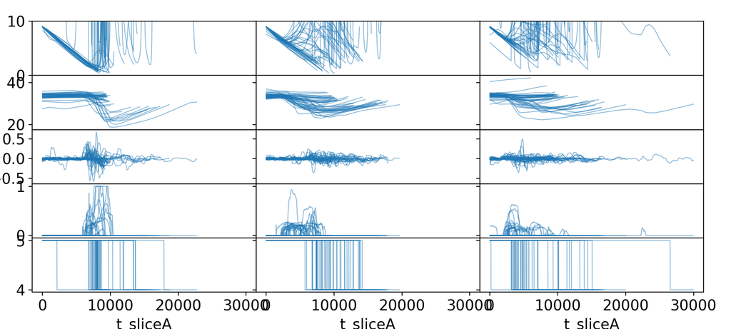

```python
# next to each other
%matplotlib notebook
r = 'nouctun' # experimental condition for left column
lw = 0.8
opa = 0.5
fig, ax = plt.subplots(5,3, sharex = True, sharey = 'row', figsize = (10,4.5))
fig.tight_layout()
# prun_df['t_sliceA'] = prun_df['t_sliceA'].apply(lambda x: x/1000)

i_p = 0
for p in participants: #participants:
    prun_df = slice_df[(slice_df['participant'] == p) & (slice_df['run'] == r)]
    for n_slice in range(1,prun_df.sliceno.max()+1):
        curslice = prun_df[prun_df.sliceno == n_slice]
        curslice.plot(x = 't_sliceA', y = 'ttc_min', ax = ax[0,0], color = 'C0', linewidth = lw, alpha = opa)
        curslice.plot(x = 't_sliceA', y = 'vEgo', ax = ax[1,0], color = 'C0', linewidth = lw, alpha = opa)


        curslice.plot(x = 't_sliceA', y = 'steer', ax = ax[2,0], color = 'C0', linewidth = lw, alpha = opa)
        curslice.plot(x = 't_sliceA', y = 'brake', ax = ax[3,0], color = 'C0', linewidth = lw, alpha = opa)
        curslice.plot(x = 't_sliceA', y = 'lane', ax = ax[4,0], color = 'C0', linewidth = lw, alpha = opa)

ax[0,0].set_ylim(0,10)

for i in range(5):
    ax[i,0].get_legend().remove()

r = 'uctun' # experimental condition for middle column

i_p = 0
for p in participants: #participants:
    prun_df = slice_df[(slice_df['participant'] == p) & (slice_df['run'] == r)]
    for n_slice in range(1,prun_df.sliceno.max()+1):
        curslice = prun_df[prun_df.sliceno == n_slice]
        curslice.plot(x = 't_sliceA', y = 'ttc_min', ax = ax[0,1], color = 'C0', linewidth = lw, alpha = opa)
        curslice.plot(x = 't_sliceA', y = 'vEgo', ax = ax[1,1], color = 'C0', linewidth = lw, alpha = opa)


        curslice.plot(x = 't_sliceA', y = 'steer', ax = ax[2,1], color = 'C0', linewidth = lw, alpha = opa)
        curslice.plot(x = 't_sliceA', y = 'brake', ax = ax[3,1], color = 'C0', linewidth = lw, alpha = opa)
        curslice.plot(x = 't_sliceA', y = 'lane', ax = ax[4,1], color = 'C0', linewidth = lw, alpha = opa)

ax[0,1].set_ylim(0,10)

for i in range(5):
    ax[i,1].get_legend().remove()


r = 'noucfog' # experimental condition for right column

i_p = 0
for p in participants: #participants:
    prun_df = slice_df[(slice_df['participant'] == p) & (slice_df['run'] == r)]
    for n_slice in range(1,prun_df.sliceno.max()+1):
        curslice = prun_df[prun_df.sliceno == n_slice]
        curslice.plot(x = 't_sliceA', y = 'ttc_min', ax = ax[0,2], color = 'C0', linewidth = lw, alpha = opa)
        curslice.plot(x = 't_sliceA', y = 'vEgo', ax = ax[1,2], color = 'C0', linewidth = lw, alpha = opa)


        curslice.plot(x = 't_sliceA', y = 'steer', ax = ax[2,2], color = 'C0', linewidth = lw, alpha = opa)
        curslice.plot(x = 't_sliceA', y = 'brake', ax = ax[3,2], color = 'C0', linewidth = lw, alpha = opa)
        curslice.plot(x = 't_sliceA', y = 'lane', ax = ax[4,2], color = 'C0', linewidth = lw, alpha = opa)

ax[0,2].set_ylim(0,10)

for i in range(5):
    ax[i,2].get_legend().remove()
fig.subplots_adjust(wspace=0, hspace=0)
plt.savefig('raw.png')
```